# Impacto del proceso de vacunación contra la Covid-19

# 8 Hipótesis

## 8.1 Dataset Fallecidos

### 8.1.1 Fecha de fallecimiento

HIPÓTESIS: ¿Cómo influye la llegada de las vacunas en la cantidad de fallecidos por COVID? En lo que va la llegada de las vacunas, el pico más alto de la cantidad de fallecidos fue obtenido durante este periodo.

### 8.1.2 Edad

HIPÓTESIS: ¿Será cierto que los adultos mayores son las personas que más fallecieron por COVID? El rango de edades de la mayor cantidad de personas que fallecieron por COVID está entre 60 y 80 años.

### 8.1.3 Sexo

HIPÓTESIS: ¿Existe alguna diferencia entre la cantidad de fallecidos y su género? En el Perú, la gran mayoría de personas fallecidas por COVID son hombres.

### 8.1.4 Departamento

HIPÓTESIS:¿Es cierto que los departamentos del Norte tienen la mayor cantidad de fallecidos por COVID? A partir de los gráficos, Lima es la ciudad con mayor cantidad de fallecidos por COVID

## 8.2 Dataset Vacunados

### 8.2.3 Dosis

HIPÓTESIS:¿Existe la misma cantidad de dosis aplicadas en las personas vacunadas del Perú? No, la mayor cantidad de dosis aplicadas es la primera.

### 8.2.4 Fabricante

HIPÓTESIS: ¿Será el mayor fabricante de vacunas del mundo (AstraZeneca) el que distribuye mayor cantidad de vacunas al Perú? El fabricante que más cantidad de vacunas distribuye al Perú es Pfizer.

### 8.2.5 Departamento

¿Es cierto que el departamento con la mayor cantidad de personas vacunadas es el mismo que de las personas fallecidas? Si, es cierto que el departamento con mayor cantidad de personas vacunadas es Lima.

# 9 Relaciones entre variables

## 9.1 Primera relación

### 9.1.1 Cantidad de fallecidos en la 2da ola por etapa de vida x Cantidad de vacunados en la 2da ola por etapa de vida

Utilities

Etapas de vida Niños(0-11 años) Adolescentes (12 - 17 años) Jóvenes(18 - 29 años) Adultos (30 -59 años) Adulto Mayor(60 a más)

Creamos dataset cantidad de fallecidos agrupados por etapa de vida

Para adultos mayores

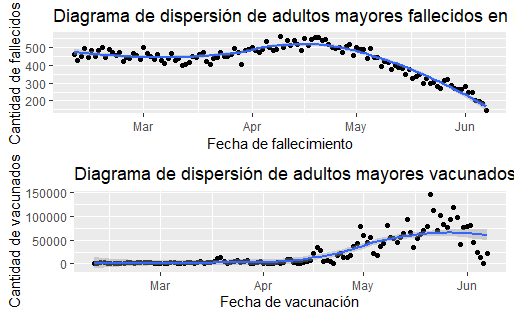

```r
graph_1 <- ggplot(DFFallAdulMay2daOla, aes(x = FECHA_FALLECIMIENTO, y = n)) +
  geom_point() + geom_smooth() +
  labs(title="Diagrama de dispersión de adultos mayores fallecidos en la 2da Ola",
       x="Fecha de fallecimiento",
       y="Cantidad de fallecidos")

graph_2 <- ggplot(DFVacAdulMay2daOla, aes(x = FECHA_VACUNACION, y = n)) +
  geom_point() + geom_smooth() +
  labs(title="Diagrama de dispersión de adultos mayores vacunados en la 2da Ola",
       x="Fecha de vacunación",
       y="Cantidad de vacunados")

multiplot(graph_1, graph_2, cols=1)
```

```r
cor(DFFallAdulMay2daOla$n, DFVacAdulMay2daOla$n)
```

```
[1] -0.5704937
```

Para adultos

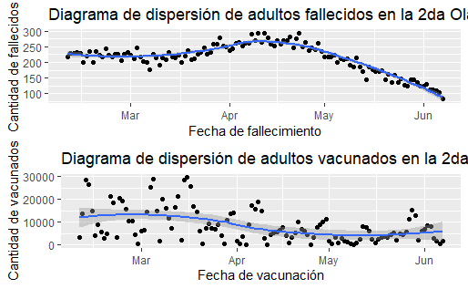

```r
graph_1 <- ggplot(DFFallAdul2daOla, aes(x = FECHA_FALLECIMIENTO, y = n)) +
  geom_point() + geom_smooth() +
  labs(title="Diagrama de dispersión de adultos fallecidos en la 2da Ola",
       x="Fecha de fallecimiento",
       y="Cantidad de fallecidos")

graph_2 <- ggplot(DFVacAdul2daOla, aes(x = FECHA_VACUNACION, y = n)) +
  geom_point() + geom_smooth() +
  labs(title="Diagrama de dispersión de adultos vacunados en la 2da Ola",
       x="Fecha de vacunación",
       y="Cantidad de vacunados")

multiplot(graph_1, graph_2, cols=1)
```

```r
cor(DFFallAdul2daOla$n, DFVacAdul2daOla$n)
```

```
[1] 0.1306875
```

Para jovenes

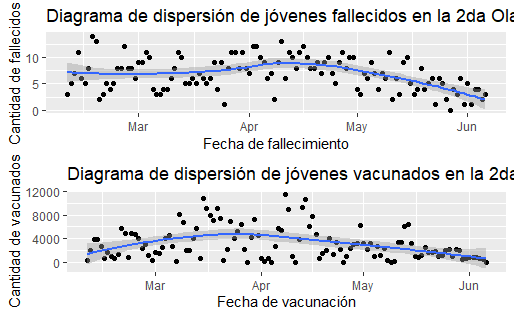

```r
graph_1 <- ggplot(DFFallJov2daOla, aes(x = FECHA_FALLECIMIENTO, y = n)) +
  geom_point() + geom_smooth() +
  labs(title="Diagrama de dispersión de jóvenes fallecidos en la 2da Ola",
       x="Fecha de fallecimiento",
       y="Cantidad de fallecidos")

graph_2 <- ggplot(DFVacJov2daOla, aes(x = FECHA_VACUNACION, y = n)) +
  geom_point() + geom_smooth() +
  labs(title="Diagrama de dispersión de jóvenes vacunados en la 2da Ola",
       x="Fecha de vacunación",
       y="Cantidad de vacunados")

multiplot(graph_1, graph_2, cols=1)
```

```r
cor(DFFallJov2daOla$n, DFVacJov2daOla$n)
```

```
[1] 0.04970341
```

## 9.2 Segunda relación

### 9.2.1 Cantidad de fallecidos por departamento en la 2da ola x Cantidad de vacunados por departamento en la 2da ola en el departamento con más vacunados

Calculamos las regiones más vacunados

```
     AMAZONAS        ANCASH      APURIMAC      AREQUIPA
        38059        136811         49402        203998
     AYACUCHO     CAJAMARCA        CALLAO         CUSCO
        68095        130355        287418        135399
 HUANCAVELICA       HUANUCO           ICA         JUNIN
        41721         64805        145645        157707
  LA LIBERTAD    LAMBAYEQUE          LIMA        LORETO
       280935        173348       2025091         83494
MADRE DE DIOS      MOQUEGUA         PASCO         PIURA
        11803         32011         23314        191276
         PUNO    SAN MARTIN         TACNA        TUMBES
        80436         76989         66323         27313
      UCAYALI
        39856
LIMA
  15
```

Vemos que Lima es el departamento que tiene más vacunados, y Madre de Dios es que el tiene menos vacunados.

Para Lima

```r
# Calculamos fallecidos por departamento
DFFallecidosCLEAN %>% select(DEPARTAMENTO, FECHA_FALLECIMIENTO) %>%
  filter(DEPARTAMENTO =="LIMA METROPOLITANA" | DEPARTAMENTO == "LIMA REGION") %>%
  filter(FECHA_FALLECIMIENTO >= as.Date("2021-02-09")) -> fall2daOlaLima
DFfall2daOlaLima <- as.data.frame(table(fall2daOlaLima$FECHA_FALLECIMIENTO),
                              col.names = c("FECHAS", "CANT_FALLECIDOS"))


# Calculamos vacunados por departamento
DFVacunadosCLEAN %>% select(DEPARTAMENTO, FECHA_VACUNACION) %>%
  filter(DEPARTAMENTO =="LIMA") %>%
  filter(FECHA_VACUNACION >= as.Date("2021-02-09") &
         FECHA_VACUNACION <= as.Date("2021-06-07")) -> vac2daOlaLima
DFvac2daOlaLima <- as.data.frame(table(vac2daOlaLima$FECHA_VACUNACION),
                              col.names = c("FECHAS", "CANT_VACUNADOS"))
cor(DFvac2daOlaLima$Freq, DFfall2daOlaLima$Freq)
```

```
[1] -0.4668205
```

Distribución de los vacunados y fallecidos en Lima en la segunda Ola

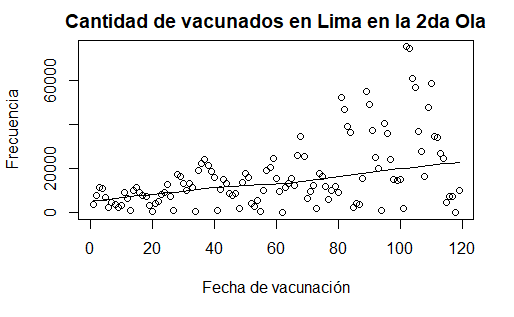

```r
# TODO arreglar grafica para que se vean las dos juntas
scatter.smooth(DFvac2daOlaLima, main="Cantidad de vacunados en Lima en la 2da Ola", xlab="Fecha de vacunación", ylab="Frecuencia")
```

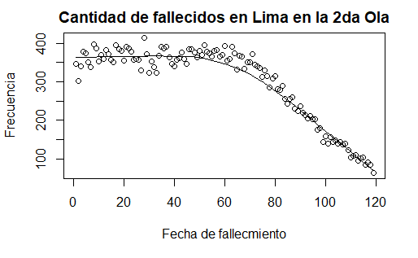

```r
scatter.smooth(DFfall2daOlaLima, main="Cantidad de fallecidos en Lima en la 2da Ola", xlab="Fecha de fallecmiento", ylab="Frecuencia")
```

## 9.3 Tercera relación

### 9.3.1 Cantidad de fallecidos por departamento en la 2da ola x Cantidad de vacunados por departamento en la 2da ola en el departamento con menos vacunados

```
     AMAZONAS        ANCASH      APURIMAC      AREQUIPA
        38059        136811         49402        203998
     AYACUCHO     CAJAMARCA        CALLAO         CUSCO
        68095        130355        287418        135399
 HUANCAVELICA       HUANUCO           ICA         JUNIN
        41721         64805        145645        157707
  LA LIBERTAD    LAMBAYEQUE          LIMA        LORETO
       280935        173348       2025091         83494
MADRE DE DIOS      MOQUEGUA         PASCO         PIURA
        11803         32011         23314        191276
         PUNO    SAN MARTIN         TACNA        TUMBES
        80436         76989         66323         27313
      UCAYALI
        39856
MADRE DE DIOS
           17
```

Vemos que Madre de Dios es el departamento que menos vacunados.

Para Madre de Dios

```r
# Calculamos fallecidos por departamento
DFFallecidosCLEAN %>% select(DEPARTAMENTO, FECHA_FALLECIMIENTO) %>%
  filter(DEPARTAMENTO =="MADRE DE DIOS") %>%
  filter(FECHA_FALLECIMIENTO >= as.Date("2021-02-09") &
           FECHA_FALLECIMIENTO <= as.Date("2021-06-03") ) -> fall2daOlaMadDios
DFfall2daOlaMadDios <- as.data.frame(table(fall2daOlaMadDios$FECHA_FALLECIMIENTO),
                              col.names = c("FECHAS", "CANT_FALLECIDOS"))

# Limpiamos los datos
s <- as.Date("2021-02-11")
e <- as.Date("2021-06-03")
daysCompleteMadDios <- seq(from=s, to=e, by=1)
fallCompleteMadDios <- c()
theDate <- s
while (theDate <= e){
  toSearch <- grep(theDate, DFfall2daOlaMadDios$Var1)
  if(!fun_int0(toSearch)){
    fallCompleteMadDios <- c(fallCompleteMadDios, 0)
  } else {
    fallCompleteMadDios <- c(fallCompleteMadDios, DFfall2daOlaMadDios$Freq[toSearch])
  }
  theDate <- theDate + 1
}
# dataset final de vacunados en la segunda ola completo
DFfall2daOlaMadDiosComplete <- data.frame(FECHAS=daysCompleteMadDios,
                                          CANTIDAD=fallCompleteMadDios)

# Calculamos vacunados por departamento
DFVacunadosCLEAN %>% select(DEPARTAMENTO, FECHA_VACUNACION) %>%
  filter(DEPARTAMENTO =="MADRE DE DIOS") %>%
  filter(FECHA_VACUNACION >= as.Date("2021-02-09") &
         FECHA_VACUNACION <= as.Date("2021-06-03")) -> vac2daOlaMadDios
DFvac2daOlaMadDios <- as.data.frame(table(vac2daOlaMadDios$FECHA_VACUNACION),
                              col.names = c("FECHAS", "CANT_VACUNADOS"))

# Limpiamos los datos
s <- as.Date("2021-02-11")
e <- as.Date("2021-06-03")
daysCompleteMadDios <- seq(from=s, to=e, by=1)
vacCompleteMadDios <- c()
theDate <- s
while (theDate <= e){
  toSearch <- grep(theDate, DFvac2daOlaMadDios$Var1)
  if(!fun_int0(toSearch)){
    vacCompleteMadDios <- c(vacCompleteMadDios, 0)
  } else {
    print(DFvac2daOlaMadDios$Freq[toSearch])
    vacCompleteMadDios <- c(vacCompleteMadDios, DFvac2daOlaMadDios$Freq[toSearch])
  }
  theDate <- theDate + 1
}
```

[output not shown]

[output cut: 73 more lines]

```r
# dataset final de vacunados en la segunda ola completo
DFvac2daOlaMadDiosComplete <- data.frame(FECHAS=daysCompleteMadDios,
                                          CANTIDAD=vacCompleteMadDios)

cor(DFfall2daOlaMadDiosComplete$CANTIDAD, DFvac2daOlaMadDiosComplete$CANTIDAD)
```

```
[1] -0.1124028
```

Distribución de los vacunados y fallecidos en Madre de Dios en la segunda Ola

```r
# TODO arreglar grafica para que se vean las dos juntas
scatter.smooth(DFfall2daOlaMadDiosComplete, main="Cantidad de vacunados en Madre de Dios en la 2da Ola", xlab="Fecha de vacunación", ylab="Frecuencia")
scatter.smooth(DFvac2daOlaMadDiosComplete, main="Cantidad de fallecidos en Madre de Dios en la 2da Ola", xlab="Fecha de fallecidos", ylab="Frecuencia")
```

[output not shown]